V The V Lab

# 公共卫生生物统计学基础

含可重复 R 示例的入门指南

公共卫生学院学习模块

更新于 2026年08月11日

**适用对象**公共卫生硕士一年级学生及公共卫生专业学生

**学习时长**约 90–120 分钟

**先修要求**掌握基本算术；无需微积分基础

关于数据 本指南中的所有记录和结果均为模拟数据。所有示例均可重复生成，且不包含任何可识别个人身份的健康信息。模拟出的关联仅用于教学，不能作为真实人群的证据。

## 如何使用本指南

各章均遵循相同的学习脉络：**为何这一概念重要**、**核心概念**、**公共卫生示例**、**R 代码**以及**结果解读检查**。请先阅读讲解，再运行或调整代码，最后展开答案面板。代码默认显示，可通过页面上的代码折叠按钮收起。

你不必记住每一个公式。请着重培养以下三个习惯：

1. 将方法与定义明确的公共卫生问题相联系；
2. 说明所作假设与不确定性；
3. 解读效应的大小和方向，而非只关注 p 值。

### 学习目标

完成本模块后，你应能够：

- 区分总体、样本、参数、统计量和目标估计量；
- 识别常见研究设计、变量类型及主要偏倚来源；
- 恰当地汇总健康数据并将其可视化；
- 计算并解读基本的频率、关联及筛查指标；
- 解释抽样变异、标准误、置信区间和 p 值；
- 选择常见的组间比较方法；
- 在不作缺乏依据的因果推断的前提下，解读简单线性回归和逻辑回归结果；
- 清晰、可重复且符合伦理地交流研究发现。

# 1 从问题到证据

## 1.1 生物统计学为何重要

**生物统计学**将统计推理应用于健康、疾病、卫生服务和人群相关问题。它并非一系列检验方法的简单集合，而是一条严谨的路径：从问题出发，形成证据，再据此作出审慎恰当的决策。

#### 描述

存在哪些健康事件、暴露和分布模式？

#### 比较

具有实际意义的组别或时间段之间差异有多大？

#### 在不确定性中学习

样本能够告诉我们目标总体的哪些信息？

一个实用的工作流程是：

> **问题 → 设计 → 测量 → 数据检查 → 描述 → 估计 → 不确定性 → 解读 → 行动**

统计方法无法弥补问题定义模糊、抽样有偏或测量质量低下等缺陷。这些关键决策早在计算 p 值之前就已作出。

## 1.2 总体、样本、参数、统计量与目标估计量

假设某城市调查了 520 名成年人，以估计流感疫苗接种覆盖率。

| 术语 | 含义 | 示例 |
| --- | --- | --- |
| **目标总体** | 研究问题所指向的完整群体 | 本季居住在该市、未居住于机构中的所有成年人 |
| **样本** | 实际观察到的人群 | 参与调查的 520 人 |
| **参数** | 固定但通常未知的总体数量特征 | 所有目标成年人中的真实疫苗接种比例 |
| **统计量／估计值** | 根据样本计算得到的数量特征 | 调查中观察到的疫苗接种比例 |
| **目标估计量** | 对拟估计对象的精确定义 | 本季目标总体中的疫苗接种覆盖率 |

**观察单位**同样至关重要。数据表中的一行可能代表一个人、一个家庭、一家诊所、一个社区或一个人日。所用方法必须与该观察单位相匹配，并妥善处理可能存在的聚集性。

### 1.2.1 将主题转化为可回答的问题

在打开 R 之前，请先明确写出：

- **总体：**目标是谁或什么？
- **暴露或干预：**要比较的是哪种状况、项目或行为？
- **结局：**研究的是哪项健康指标？它如何定义？
- **比较：**与谁、什么或哪个时间点进行比较？
- **时间：**是在某一时点、某一时间段内，还是直至某事件发生？
- **目标估计量：**是患病率、风险差、风险比、均值差、率比，还是其他数量？

问题示例 在冬季开始时居住于该市的成年人中（总体），已接种疫苗者与未接种疫苗者相比（比较），12 周内发生实验室确诊呼吸道感染（结局）的风险是多少？结果以风险比表示（目标估计量）。

**检查理解：识别参数**

在 800 名高中生的随机样本中，18% 报告目前使用电子烟。这里的参数是什么？

**答案：**参数是所定义目标总体中目前使用电子烟的学生真实比例。观察到的 18% 是样本统计量。它能否良好估计该参数，取决于抽样、测量和未应答情况。

# 2 数据、研究设计与偏倚

## 2.1 变量的角色与类型

变量所扮演的角色取决于研究问题。

- **结局**是关注的反应变量或健康终点。
- **暴露**或**干预**是所比较的主要条件。
- **协变量**是另一项已测量特征，可用于描述、提高精度、控制混杂或评估效应修饰。
- **标识符**用于标记观察单位，通常不作为健康测量指标进行分析。

| 变量类型 | 记录内容 | 公共卫生示例 | 常用汇总指标 |
| --- | --- | --- | --- |
| 名义分类变量 | 无顺序的类别标签 | 社区、诊所 | 频数和比例 |
| 有序分类变量 | 有顺序但类别间距未知的标签 | 自评健康：从差到极好 | 频数、比例、中位类别 |
| 二分类变量 | 两个类别 | 是否接种疫苗：是／否 | 频数和比例 |
| 离散计数变量 | 非负的事件次数 | 一年内急诊就诊次数 | 均值、方差、率；通常使用计数模型 |
| 连续变量 | 测得的数值 | 血压、年龄、BMI | 均值／标准差或中位数／四分位距 |
| 事件发生时间变量 | 至事件发生或删失的时间 | 至复发的时间 | 生存概率、风险率、中位生存时间 |

不要仅凭变量的存储格式选择汇总方法。以数字存储的邮政编码仍是分类变量，五级评分通常是有序变量，而非真正的连续变量。

## 2.2 常见公共卫生研究设计

| 设计 | 如何开始 | 适用目的 | 主要注意事项 |
| --- | --- | --- | --- |
| 横断面调查 | 在某一时点或较短时间段内抽取人群样本 | 患病率和当前分布模式 | 暴露与结局的时间先后可能不清楚 |
| 队列研究 | 按暴露情况分组并随访结局 | 发病、风险、率及时间顺序 | 失访和混杂 |
| 病例对照研究 | 抽取病例和对照，再评估既往暴露 | 罕见结局或潜伏期较长的结局 | 选择偏倚／回忆偏倚；无法从抽样所得表格直接估计风险 |
| 随机试验 | 随机分配干预 | 试验条件下的干预效应 | 依从性、失访、伦理及结果的可推广性 |
| 整群随机试验 | 将学校、诊所或社区随机分组 | 人群层面的项目 | 同一群组内的结局彼此相关 |
| 监测系统 | 持续收集已明确定义的事件 | 趋势、信号和项目监测 | 病例定义、检测方式和完整性的变化 |

研究设计决定结果解读 横断面研究中的关联无法确定变量出现的时间先后。病例对照研究所得优势比在其抽样设计下是有效的，但样本中的病例比例并非疾病患病率。分析聚集数据时，需要采用能够处理群组内相似性的方法。

## 2.3 偏倚、随机性与混杂

三者是不同的问题：

| 问题 | 通俗含义 | 示例 | 常见应对方式 |
| --- | --- | --- | --- |
| **随机性** | 不同随机样本所得结果会有所不同 | 一个样本中的覆盖率为 68%，另一个样本中为 71% | 用标准误和置信区间量化 |
| **选择偏倚** | 是否被纳入研究与研究问题中的重要变量有关 | 网络调查遗漏了无法上网的居民 | 改进抽样和招募；评估未应答 |
| **信息偏倚** | 暴露或结局的测量方式存在差异或测量不准确 | 病例对既往暴露的回忆比对照更完整 | 尽可能采用有效、标准化且设盲的测量方法 |
| **混杂** | 一个共同原因造成或扭曲暴露与结局之间的关联 | 年龄同时影响疫苗接种和感染风险 | 依据专业知识与因果推理进行研究设计和分析 |

混杂并非简单的“任意第三变量”，也不能仅凭较小的 p 值来判定。只有在协变量、模型、测量和因果假设均恰当时，调整才有助于减少混杂。

**检查理解：判断研究设计及一种可能的偏倚**

研究者选取 300 名肺癌患者和 300 名未患肺癌者，并询问他们 30 年前的职业性石棉暴露情况。

**答案：**这是一项病例对照研究。病例与对照对久远暴露史的回忆或重建可能存在差异，从而造成信息偏倚；对照的选择也可能造成选择偏倚。对于这种抽样所得的 2×2 表，优势比是自然的关联指标。

# 3 健康数据的描述与可视化

## 3.1 首先检查数据

下面展示模拟教学数据集的前几行。切勿在检查变量名、单位、类别、不可能值、重复记录和缺失情况之前就直接进行统计检验。

```r
dim(ph_data)
```

```
## [1] 520  10
```

```r
head(
  ph_data[c(
    "participant_id", "age", "neighborhood", "smoking_status",
    "physical_activity_min_week", "systolic_bp"
  )],
  6
)
```

| participant_id | age | neighborhood | smoking_status | physical_activity_min_week | systolic_bp |
| --- | --- | --- | --- | --- | --- |
| P001 | 20 | North | Not current | 80 | 114 |
| P002 | 27 | South | Current | 81 | 110 |
| P003 | 58 | Central | Not current | 76 | 130 |
| P004 | 28 | Central | Not current | 6 | 116 |
| P005 | 35 | Central | Not current | 284 | 98 |
| P006 | 64 | West | Not current | 68 | 124 |

```r
colSums(is.na(ph_data))
```

```
##             participant_id                        age               neighborhood
##                          0                          0                          0
##             smoking_status physical_activity_min_week                        bmi
##                          0                         18                          0
##                systolic_bp             access_to_care                 vaccinated
##                          0                          0                          0
##      respiratory_infection
##                          0
```

缺失的身体活动值编码为 `NA`，而不是零。零表示测得的活动量为零；`NA` 表示该值未知。

## 3.2 集中趋势与离散程度

- **均值**使用每一个观测值，因此容易受到极端观测值的影响。
- **中位数**是排序后位于中间的数值，对极端观测值不敏感。
- **标准差（SD）**描述观测值围绕其均值的变异程度。
- **四分位距（IQR）**涵盖第 25 百分位数至第 75 百分位数，对极端值不敏感。

如果分布大致对称，且均值与标准差能够回答研究问题，可使用均值和标准差。对于明显偏斜的分布，或当典型排序位置更有意义时，应使用中位数和四分位距。无论如何，都应先查看数据分布。

```r
summary_table <- data.frame(
  Variable = c("年龄（岁）", "收缩压（mmHg）",
               "身体活动（分钟／周）"),
  N_observed = c(sum(!is.na(ph_data$age)),
                 sum(!is.na(ph_data$systolic_bp)),
                 sum(!is.na(ph_data$physical_activity_min_week))),
  Mean = c(mean(ph_data$age), mean(ph_data$systolic_bp),
           mean(ph_data$physical_activity_min_week, na.rm = TRUE)),
  SD = c(sd(ph_data$age), sd(ph_data$systolic_bp),
         sd(ph_data$physical_activity_min_week, na.rm = TRUE)),
  Median = c(median(ph_data$age), median(ph_data$systolic_bp),
             median(ph_data$physical_activity_min_week, na.rm = TRUE)),
  IQR = c(IQR(ph_data$age), IQR(ph_data$systolic_bp),
          IQR(ph_data$physical_activity_min_week, na.rm = TRUE))
)

knitr::kable(
  summary_table,
  digits = 1,
  col.names = c("变量", "观测数", "均值", "标准差", "中位数", "四分位距"),
  caption = "模拟参与者数据的描述性统计"
)
```

模拟参与者数据的描述性统计

| 变量 | 观测数 | 均值 | 标准差 | 中位数 | 四分位距 |
| --- | --- | --- | --- | --- | --- |
| 年龄（岁） | 520 | 44 | 15.5 | 44 | 23 |
| 收缩压（mmHg） | 520 | 124 | 14.4 | 123 | 19 |
| 身体活动（分钟／周） | 502 | 119 | 97.3 | 97 | 112 |

### 3.2.1 根据问题选择图形

- **条形图：**比较各类别的频数或比例。
- **直方图：**展示一个连续变量的分布形状。
- **箱线图：**比较不同组别的连续变量分布。
- **散点图：**展示两个连续变量之间的关系。
- **折线图：**展示按时间排序的某项指标。

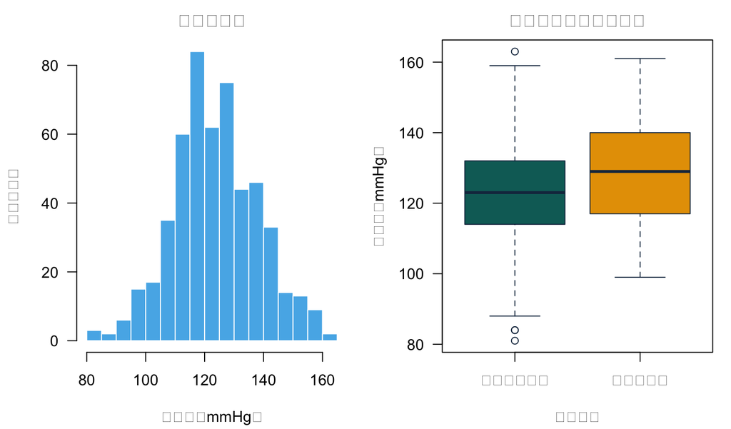

在该模拟样本中，收缩压大致呈单峰分布，其分布因当前吸烟状态而有所不同。

```r
old_par <- par(mfrow = c(1, 2), mar = c(4.2, 4.2, 2.2, 1), las = 1)

hist(
  ph_data$systolic_bp,
  breaks = "FD",
  col = palette_ph["sky"],
  border = "white",
  main = "收缩压分布",
  xlab = "收缩压（mmHg）",
  ylab = "参与者人数"
)

boxplot(
  systolic_bp ~ smoking_status,
  data = ph_data,
  col = c(palette_ph["teal"], palette_ph["orange"]),
  border = palette_ph["navy"],
  names = c("非当前吸烟者", "当前吸烟者"),
  main = "不同吸烟状态的收缩压",
  xlab = "吸烟状态",
  ylab = "收缩压（mmHg）"
)
```

```r
par(old_par)
```

图形呈现的诚信原则 应标明单位，说明百分比所对应的分母，保持时间顺序，并解释数据排除情况。截断纵轴可能夸大小幅差异。三维效果和彩虹色板会增加视觉干扰，并可能降低可访问性。

## 3.3 频数、比例、风险与率

- **频数**是事件数或人数。
- **比例**的分子包含于分母之中，取值范围为 0 到 1。
- **患病率**是在某一指定时点或规定时间段内已患某病的比例。
- **累积发病率（风险）**是在规定时间段内，新发病例数除以期初处于风险中的人群数。
- **发病密度**是新发病例数除以累积的风险人时。
- **比**用于比较两个数量；分子不一定是分母的一部分。

始终应说明总体、时间窗口、分子和分母。“率为 12%”这种表述含义不清，因为百分数通常描述比例，而率通常以人时为单位。

```r
vaccination_counts <- table(ph_data$vaccinated)
vaccination_summary <- data.frame(
  Vaccinated = names(vaccination_counts),
  Count = as.vector(vaccination_counts),
  Proportion = as.vector(vaccination_counts) / sum(vaccination_counts)
)

knitr::kable(
  vaccination_summary,
  digits = 3,
  col.names = c("疫苗接种状态", "频数", "比例"),
  caption = "模拟样本中的疫苗接种状态"
)
```

模拟样本中的疫苗接种状态

| 疫苗接种状态 | 频数 | 比例 |
| --- | --- | --- |
| No | 151 | 0.29 |
| Yes | 369 | 0.71 |

**检查理解：选择汇总指标**

急诊科等待时间明显右偏，因为少数患者需要等待数小时。均值／标准差与中位数／四分位距相比，哪一组指标更有信息价值？

**答案：**对于明显偏斜的分布，中位数和四分位距通常更能代表其集中趋势和离散程度。如果标注清楚，补充报告特定百分位数或将均值作为具有政策意义的附加指标，仍可能有用。

# 4 概率与抽样变异性

## 4.1 健康问题中的概率

概率的取值范围为 0（不可能）到 1（必然）。对于事件 $A$：

补集法则：$P(A^c) = 1 - P(A)$

条件概率 $P(A \mid B)$ 是在满足 $B$ 的个体中发生 $A$ 的概率。分母的界定至关重要。例如，灵敏度是**在真正患有该病的人群中**检测结果为阳性的概率。

如果得知事件 $A$ 与 $B$ 中的一个发生，不会改变另一个事件发生的概率，则二者相互独立：

独立性：$P(A\cap B) = P(A)P(B)$

独立性是需要论证的假设，而不是默认条件。同一个人的重复观测，以及同一家庭成员的观测，往往彼此相关。

## 4.2 三种常用概率分布

| 分布 | 可表示的情形 | 关键条件 |
| --- | --- | --- |
| 二项分布 | 在固定数量、暴露情况相近的人群中的感染人数 | 试验次数固定、每次只有两种结果、概率相同、各次试验相互独立 |
| 正态分布 | 对称的连续测量值或抽样分布 | 在适当情境下可用钟形曲线近似 |
| 泊松分布 | 指定时间或空间范围内的事件数 | 事件以近似稳定的速率发生；其均值与方差的关系可能过于严格 |

真实数据可能不满足这些条件。例如，传染病例会出现聚集，其变异程度可能超过简单泊松模型所允许的范围。

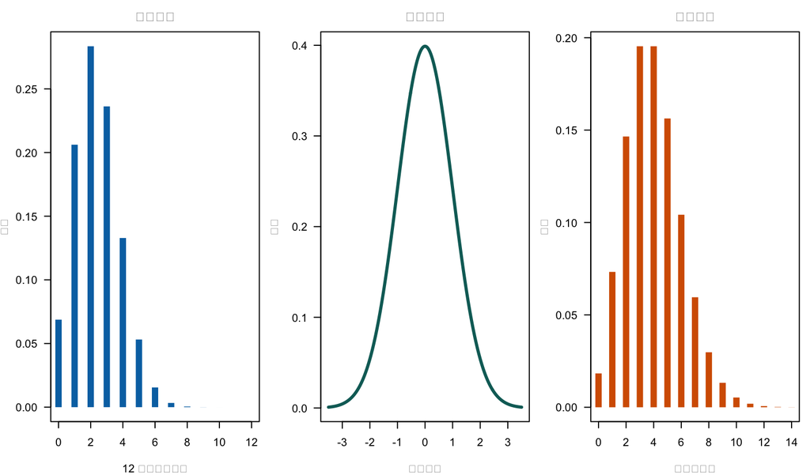

二项、正态和泊松概率模型示例。每种模型回答的问题类型各不相同。

```r
old_par <- par(mfrow = c(1, 3), mar = c(4, 3.8, 2.4, 0.8), las = 1)

x_bin <- 0:12
plot(x_bin, dbinom(x_bin, size = 12, prob = 0.20), type = "h", lwd = 6,
     lend = 1, col = palette_ph["blue"],
     xlab = "12 人中的病例数", ylab = "概率", main = "二项分布")

x_norm <- seq(-3.5, 3.5, length.out = 300)
plot(x_norm, dnorm(x_norm), type = "l", lwd = 3,
     col = palette_ph["teal"],
     xlab = "标准化值", ylab = "密度", main = "正态分布")

x_pois <- 0:14
plot(x_pois, dpois(x_pois, lambda = 4), type = "h", lwd = 6,
     lend = 1, col = palette_ph["vermillion"],
     xlab = "每日事件数", ylab = "概率", main = "泊松分布")
```

```r
par(old_par)
```

## 4.3 抽样分布与标准误

如果反复抽取随机样本并计算某个估计量，这些估计值便构成一个**抽样分布**。该分布的标准差就是估计量的**标准误（SE）**。对于来自方差有限的同一总体且相互独立的观测，样本均值的标准误估计为：

标准误估计：$\widehat{SE}(\bar{x}) = s/\sqrt{n}$

标准差（SD）描述的是**观测值之间**的变异；标准误（SE）描述的是**估计值的不确定性**。二者不能互换。

由于我们只有一个样本，真实的抽样分布未知。**非参数自助法**通过按照原样本量，从观测数据中反复进行有放回抽样来近似该分布。此时经验样本暂时替代未知总体；这种近似无法纠正有偏或缺乏代表性的样本。

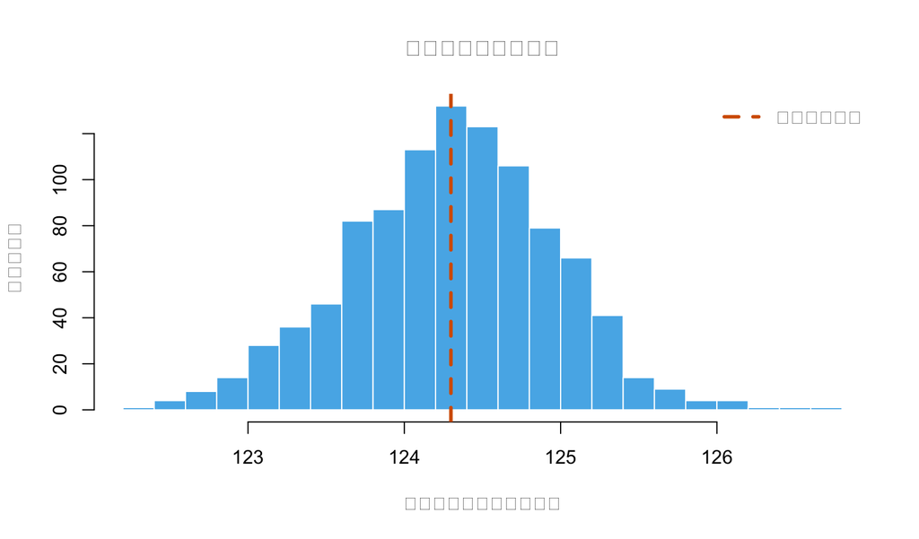

样本均值的自助抽样分布以观测均值附近为中心。虚线表示观测到的样本均值。

```r
set.seed(410)
bootstrap_means <- replicate(
  1000,
  mean(sample(ph_data$systolic_bp, size = nrow(ph_data), replace = TRUE))
)

hist(bootstrap_means, breaks = 24, col = palette_ph["sky"], border = "white",
     main = "均值的自助抽样分布",
     xlab = "自助样本中的平均收缩压",
     ylab = "自助样本数")
abline(v = mean(ph_data$systolic_bp), col = palette_ph["vermillion"],
       lwd = 3, lty = 2)
legend("topright", legend = "观测样本均值", lty = 2, lwd = 3,
       col = palette_ph["vermillion"], bty = "n")
```

由于标准误通常按 $1/\sqrt{n}$ 的比例减小，将样本量增加到原来的四倍，大约只能使标准误减半，而不是降为四分之一。对于聚类、配对、加权或其他存在依赖关系的观测，这个简单公式不能原样套用；标准误的计算必须反映研究设计。

```r
se_example <- data.frame(
  Sample_size = c(25, 100, 400),
  Assumed_SD = 16,
  Standard_error = 16 / sqrt(c(25, 100, 400))
)
knitr::kable(se_example, digits = 1,
             col.names = c("样本量", "假定的标准差", "标准误"),
             caption = "标准差为 16 时，样本量如何改变标准误")
```

标准差为 16 时，样本量如何改变标准误

| 样本量 | 假定的标准差 | 标准误 |
| --- | --- | --- |
| 25 | 16 | 3.2 |
| 100 | 16 | 1.6 |
| 400 | 16 | 0.8 |

**检验你的理解：SD 还是 SE？**

某报告称：“平均收缩压为 128 mmHg（SD 17）。”这里的 17 描述的是什么？

**答案：** 它描述的是参与者血压值围绕样本均值的变异程度，并不直接表示总体均值估计的不确定性；后者由标准误描述。

# 5 估计与置信区间

## 5.1 点估计与区间估计

**点估计**是根据数据得到的单一最佳估计值。**区间估计**用于表达抽样不确定性。95% 置信区间（CI）由估计值、标准误以及适当的参考分布共同确定。

在常见条件下，均值的置信区间为：

估计值 ± 临界值 × 标准误

```r
# 基于 t 分布计算平均收缩压的置信区间。
n_bp <- sum(!is.na(ph_data$systolic_bp))
mean_bp <- mean(ph_data$systolic_bp, na.rm = TRUE)
se_bp <- sd(ph_data$systolic_bp, na.rm = TRUE) / sqrt(n_bp)
ci_mean_bp <- mean_bp + c(-1, 1) * qt(0.975, df = n_bp - 1) * se_bp

# 基于得分法计算疫苗接种比例的置信区间。
x_vax <- sum(ph_data$vaccinated == "Yes")
n_vax <- sum(!is.na(ph_data$vaccinated))
vax_ci_object <- prop.test(x_vax, n_vax, correct = FALSE)
vax_estimate <- unname(vax_ci_object$estimate)
vax_ci <- vax_ci_object$conf.int

ci_table <- data.frame(
  Quantity = c("平均收缩压（mmHg）", "疫苗接种比例"),
  Estimate = c(mean_bp, vax_estimate),
  Lower_95_CI = c(ci_mean_bp[1], vax_ci[1]),
  Upper_95_CI = c(ci_mean_bp[2], vax_ci[2])
)

knitr::kable(ci_table, digits = 3,
             col.names = c("指标", "估计值", "95% 置信区间下限", "95% 置信区间上限"),
             caption = "模拟样本的点估计与区间估计")
```

模拟样本的点估计与区间估计

| 指标 | 估计值 | 95% 置信区间下限 | 95% 置信区间上限 |
| --- | --- | --- | --- |
| 平均收缩压（mmHg） | 124.30 | 123.060 | 125.536 |
| 疫苗接种比例 | 0.71 | 0.669 | 0.747 |

估计的平均收缩压为 124.3 mmHg（95% CI：123.1 至 125.5）。在模型与抽样假设成立的前提下，该区间描述的是总体均值的不确定性，而不是包含 95% 个体血压值的范围。

### 5.1.1 “95% 置信”意味着什么

如果反复采用同一种有效的抽样方法和区间估计程序，所得区间中约有 95% 会包含真实参数。计算出一个具体区间后，参数是固定的；按照标准的频率学派解释，不能说这个特定区间有 95% 的概率包含真实参数。

置信区间的宽度反映模型下的随机不确定性。它**不会**自动涵盖选择偏倚、测量误差、未控制的混杂、模型设定错误或数据处理错误。

区间不是“通过/不通过”的判定工具 围绕微小效应的窄区间可能并不重要；宽区间则可能同时包含具有实际意义的获益与危害。应结合估计值、区间界限、单位、研究设计和公共卫生情境进行解释。

**检验你的理解：解释 95% 置信区间**

某风险差为 −4 个百分点，95% 置信区间为 −9 至 +1 个百分点。应如何谨慎解释？

**答案：** 在相关假设成立的前提下，数据所支持的效应范围从具有实际意义的降低到小幅增加。由于区间包含 0，在双侧 5% 显著性水平下，数据不能拒绝差异为 0；但“差异无统计学显著性”并不能证明效应不存在。

# 6 假设检验与组间比较

## 6.1 零假设与 p 值

假设检验从一个**零假设** $H_0$ 开始，通常表示无差异或无关联，并设有备择假设 $H_A$。p 值是：

> 在零假设和模型假设成立的前提下，获得与零假设至少像观测数据这样不相容的数据的概率。

p 值**不是**零假设为真的概率，不是结果“由偶然造成”的概率，也不是效应大小。

- **I 型错误**是拒绝了真实的零假设。
- **II 型错误**是未能拒绝错误的零假设。
- **检验效能**是在给定设计和特定真实效应下拒绝零假设的概率。

检验效能取决于样本量、变异程度、效应大小、结局频率、研究设计、缺失情况以及所选显著性阈值。在条件允许时，应在收集数据之前规划检验效能。

## 6.2 韦尔奇两独立样本 t 检验

韦尔奇 t 检验不要求两组方差相等，因此通常是比较两个独立均值的合理默认方法。这里用它比较不同当前吸烟状态人群的平均收缩压。

```r
bp_test <- t.test(systolic_bp ~ smoking_status, data = ph_data)
bp_means <- aggregate(systolic_bp ~ smoking_status, data = ph_data, mean)
knitr::kable(bp_means, digits = 1,
             col.names = c("当前吸烟状态", "平均收缩压（mmHg）"),
             caption = "按当前吸烟状态分组的平均收缩压")
```

按当前吸烟状态分组的平均收缩压

| 当前吸烟状态 | 平均收缩压（mmHg） |
| --- | --- |
| Not current | 123 |
| Current | 129 |

将差值定义为当前吸烟者减去非当前吸烟者时，估计的均值差为 5.6 mmHg。双侧 p 值为 0.0011。这一模拟的观察性比较反映的是关联，不能说明吸烟导致了该差异，因为两组的其他特征也可能不同。

### 6.2.1 根据研究问题与设计选择方法

| 研究问题 | 常见的入门方法 | 重要检查事项 |
| --- | --- | --- |
| 比较两个独立均值 | 韦尔奇两独立样本 t 检验 | 观测单位相互独立；检查分布和强影响观测值 |
| 比较配对的前后测量值 | 对个体内差值进行配对 t 检验 | 配对关系正确；检查差值分布 |
| 比较两个分类变量 | 卡方独立性检验 | 检查期望格数；数据稀疏时使用费舍尔精确检验 |
| 比较有序或高度偏态的结局 | 适当时采用基于秩的方法 | 秩和检验并不自动等同于中位数检验 |
| 估计调整后的连续型关联 | 线性回归 | 函数形式、残差模式、强影响观测值 |
| 估计调整后的二分类关联 | 逻辑回归 | 模型设定正确、数据稀疏性、优势比的解释 |

统计学显著不等于具有公共卫生重要性 大样本可能使很小的效应得到很小的 p 值，小型研究则可能漏掉重要效应。应报告效应估计值、置信区间、单位、可能时的绝对风险、相关假设及后果，而不能只报告 p 是否 < 0.05。

多重检验同样需要重视。检验大量假设时，出现假阳性结果的可能性会增加。应预先指定主要研究问题，限制机会性检验，并在科学情境需要时采用多重性校正方法。

**检验你的理解：解释 p = 0.03**

以下哪种说法正确：“零假设为真的概率是 3%”，还是“如果零假设和模型假设成立，得到至少像当前结果这样与零假设不相容的结果，其发生概率约为 3%”？

**答案：** 第二种说法正确。第一种说法错误地将 p 值当作 $P(H_0 \mid data)$。p 值并不提供这个概率。

# 7 频率与关联指标

## 7.1 队列研究形式的 2×2 表

假设对 240 名工人随访一个呼吸道疾病暴发期。

|  | 患病 | 未患病 | 合计 |
| --- | --- | --- | --- |
| 暴露组 | $a=48$ | $b=72$ | 120 |
| 未暴露组 | $c=24$ | $d=96$ | 120 |

两组的风险分别为：

暴露组风险 = $a/(a+b)$；未暴露组风险 = $c/(c+d)$

以下三种常见关联指标回答不同的问题：

风险差：$RD = a/(a+b) - c/(c+d)$

风险比：$RR = [a/(a+b)]/[c/(c+d)]$

优势比：$OR = ad/(bc)$

```r
a <- 48; b <- 72; c <- 24; d <- 96
risk_exposed <- a / (a + b)
risk_unexposed <- c / (c + d)
risk_difference <- risk_exposed - risk_unexposed
risk_ratio <- risk_exposed / risk_unexposed
odds_ratio <- (a * d) / (b * c)

# 用于教学演示的大样本置信区间。
se_rd <- sqrt(risk_exposed * (1 - risk_exposed) / (a + b) +
                risk_unexposed * (1 - risk_unexposed) / (c + d))
ci_rd <- risk_difference + c(-1, 1) * 1.96 * se_rd

se_log_rr <- sqrt(1 / a - 1 / (a + b) + 1 / c - 1 / (c + d))
ci_rr <- exp(log(risk_ratio) + c(-1, 1) * 1.96 * se_log_rr)

se_log_or <- sqrt(1 / a + 1 / b + 1 / c + 1 / d)
ci_or <- exp(log(odds_ratio) + c(-1, 1) * 1.96 * se_log_or)

effect_table <- data.frame(
  Measure = c("风险差", "风险比", "优势比"),
  Estimate = c(risk_difference, risk_ratio, odds_ratio),
  Lower_95_CI = c(ci_rd[1], ci_rr[1], ci_or[1]),
  Upper_95_CI = c(ci_rd[2], ci_rr[2], ci_or[2])
)

knitr::kable(effect_table, digits = 2,
             col.names = c("指标", "估计值", "95% 置信区间下限", "95% 置信区间上限"),
             caption = "暴发示例中未经调整的关联指标")
```

暴发示例中未经调整的关联指标

| 指标 | 估计值 | 95% 置信区间下限 | 95% 置信区间上限 |
| --- | --- | --- | --- |
| 风险差 | 0.20 | 0.09 | 0.31 |
| 风险比 | 2.00 | 1.31 | 3.04 |
| 优势比 | 2.67 | 1.50 | 4.75 |

暴露组工人的患病风险为 40%，未暴露组为 20%。估计风险差为 20 个百分点，即在本次暴发期内，每 100 名工人中增加 20 例病例。风险比为 2.0，表示暴露组观察到的风险是未暴露组的两倍。优势比为 2.67，不应将其误称为风险比。

### 7.1.1 选择关联指标

- **风险差**表示风险的绝对增加或降低，通常可直接用于项目规划。
- **风险比**表示规定时期内的相对风险。
- **优势比**比较两组的优势。它自然产生于逻辑回归和病例-对照抽样。
- 当结局少见时，优势比可能近似风险比；当结局常见时，二者的数值可能相差很大。

这些计算均未经调整。存在混杂、聚类、删失、随访时间不等或复杂抽样时，可能需要采用其他方法。

**检验你的理解：绝对效应与相对效应**

某干预将风险从 2% 降至 1%。风险差和风险比分别是多少？

**答案：** 风险差为 −1 个百分点（1% − 2%）；风险比为 0.50（1% / 2%），即相对降低 50%。两者都正确，但传达的信息不同。

# 8 筛查与诊断试验

## 8.1 评价试验性能需要参考标准

设想一个包含 1,000 人的筛查项目。参考标准判定其中 80 人患有该病。筛查试验得到以下结果：

|  | 患病 | 未患病 | 合计 |
| --- | --- | --- | --- |
| 检测阳性 | TP = 68 | FP = 92 | 160 |
| 检测阴性 | FN = 12 | TN = 828 | 840 |
| 合计 | 80 | 920 | 1,000 |

灵敏度 = $TP/(TP+FN)$；特异度 = $TN/(TN+FP)$

PPV = $TP/(TP+FP)$；NPV = $TN/(TN+FN)$

```r
tp <- 68; fp <- 92; fn <- 12; tn <- 828
screening <- data.frame(
  Measure = c("灵敏度", "特异度", "阳性预测值",
              "阴性预测值"),
  Estimate = c(tp / (tp + fn), tn / (tn + fp),
               tp / (tp + fp), tn / (tn + fn))
)
knitr::kable(screening, digits = 3,
             col.names = c("指标", "估计值"),
             caption = "假设项目中的筛查性能")
```

假设项目中的筛查性能

| 指标 | 估计值 |
| --- | --- |
| 灵敏度 | 0.850 |
| 特异度 | 0.900 |
| 阳性预测值 | 0.425 |
| 阴性预测值 | 0.986 |

灵敏度为 85%，特异度为 90%。然而，在检测阳性者中，真正患病的比例只有 42.5%（PPV）。出现这一差异，是因为该筛查人群的患病率为 8%，而人数多得多的未患病组会累积较多假阳性结果。

## 8.2 预测值随患病率变化

当灵敏度和特异度固定时，PPV 通常随患病率升高而升高，NPV 通常随之降低。

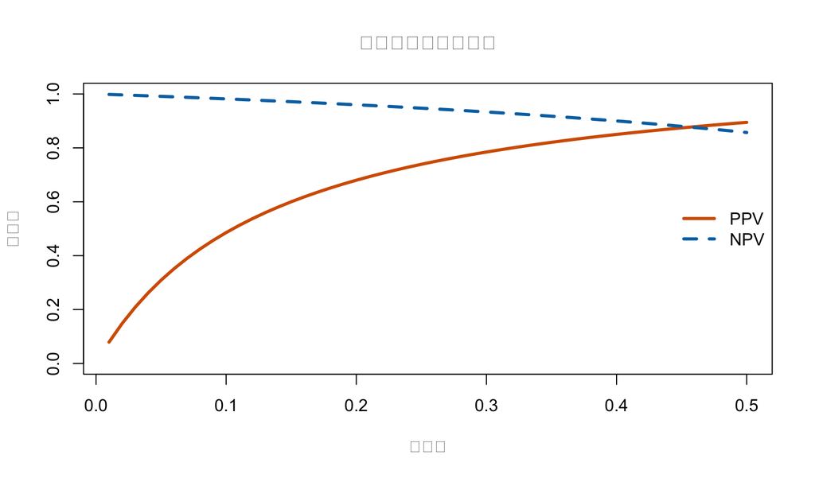

即使灵敏度固定为 85%、特异度固定为 90%，预测值仍会随患病率变化。

```r
prevalence_grid <- seq(0.01, 0.50, by = 0.01)
sens <- 0.85
spec <- 0.90
ppv_grid <- sens * prevalence_grid /
  (sens * prevalence_grid + (1 - spec) * (1 - prevalence_grid))
npv_grid <- spec * (1 - prevalence_grid) /
  ((1 - sens) * prevalence_grid + spec * (1 - prevalence_grid))

plot(prevalence_grid, ppv_grid, type = "l", lwd = 3,
     col = palette_ph["vermillion"], ylim = c(0, 1),
     xlab = "患病率", ylab = "预测值",
     main = "预测值取决于患病率")
lines(prevalence_grid, npv_grid, lwd = 3, lty = 2,
      col = palette_ph["blue"])
legend("right", legend = c("PPV", "NPV"), lwd = 3, lty = c(1, 2),
       col = c(palette_ph["vermillion"], palette_ph["blue"]), bty = "n")
```

提高灵敏度的阈值选择通常会降低特异度，反之亦然。应如何权衡，取决于漏诊、误报的后果，以及随访资源和公平性。由于疾病谱和验证过程不同，灵敏度和特异度也可能因人群而异。

**检验你的理解：应该使用哪个分母？**

计算灵敏度时，分母应为所有检测阳性者，还是所有真正患病者？

**答案：** 分母应为所有真正患病者，即 (TP+FN)。在检测阳性者中，真阳性所占比例是 PPV，其分母为 (TP+FP)。

# 9 相关与回归基础

## 9.1 相关性是一种描述，而非因果结论

皮尔逊相关系数概括两个数值变量之间线性关系的强度。斯皮尔曼相关系数概括单调的秩相关关系。离群值、受限的取值范围、混合的亚组以及非线性模式都可能影响这两种相关系数。

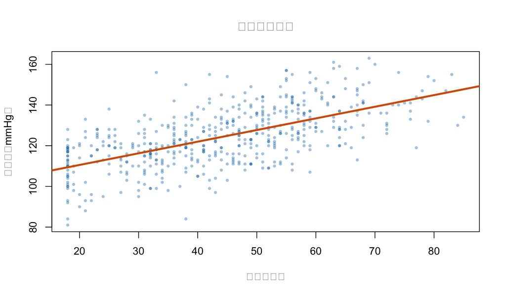

在模拟数据中，收缩压往往随年龄增加而升高，但个体之间存在较大差异。

```r
plot(ph_data$age, ph_data$systolic_bp,
     pch = 16, cex = 0.65, col = rgb(0, 114/255, 178/255, 0.38),
     xlab = "年龄（岁）", ylab = "收缩压（mmHg）",
     main = "年龄与收缩压")
abline(lm(systolic_bp ~ age, data = ph_data),
       col = palette_ph["vermillion"], lwd = 3)
```

皮尔逊相关系数为 0.62。该数值并不能证明年龄的变化会使血压发生某个特定幅度的变化。要作因果解释，除了相关性之外，还需要合理、可辩护的研究设计与假设。

## 9.2 连续结局的线性回归

多元线性模型可以将平均收缩压描述为若干协变量的函数：

$E(Y\mid X) = \beta_0 + \beta_1X_1 + \beta_2X_2 + \cdots$

```r
bp_model <- lm(systolic_bp ~ age + bmi + smoking_status, data = ph_data)
coef_table <- summary(bp_model)$coefficients
coef_table_display <- coef_table
rownames(coef_table_display) <- c(
  "截距", "年龄（每增加 1 岁）", "体重指数（每增加 1 单位）",
  "当前吸烟（参照：当前不吸烟）"
)
knitr::kable(
  coef_table_display,
  digits = 3,
  col.names = c("估计值", "标准误", "t 值", "p 值"),
  caption = "收缩压的线性回归"
)
```

收缩压的线性回归

|  | 估计值 | 标准误 | t 值 | p 值 |
| --- | --- | --- | --- | --- |
| 截距 | 90.533 | 3.220 | 28.12 | 0.000 |
| 年龄（每增加 1 岁） | 0.569 | 0.032 | 17.99 | 0.000 |
| 体重指数（每增加 1 单位） | 0.308 | 0.108 | 2.85 | 0.005 |
| 当前吸烟（参照：当前不吸烟） | 3.532 | 1.265 | 2.79 | 0.005 |

年龄的回归系数为每增加 1 岁 0.57 mmHg。在该模型中，体重指数和吸烟状态相同而年龄相差 1 岁的参与者，其平均收缩压相差约 0.57 mmHg。这个系数表示调整后的关联，并不自然等同于因果效应。

应检查残差模式、线性关系、有影响力的观测、观测间依赖性，以及用线性模型描述条件均值在科学上是否合理。样本量很大也无法弥补错误的函数形式。

## 9.3 二元结局的逻辑回归

逻辑回归对二元结局优势的对数进行建模。将回归系数取指数得到的是**优势比**，而不是风险比。

```r
infection_model <- glm(
  respiratory_infection ~ vaccinated + age + smoking_status + neighborhood,
  data = ph_data,
  family = binomial()
)

model_coef <- summary(infection_model)$coefficients
non_intercept <- rownames(model_coef) != "(Intercept)"
or_table <- data.frame(
  Term = rownames(model_coef)[non_intercept],
  Odds_ratio = exp(model_coef[non_intercept, "Estimate"]),
  Lower_95_CI = exp(model_coef[non_intercept, "Estimate"] -
                      1.96 * model_coef[non_intercept, "Std. Error"]),
  Upper_95_CI = exp(model_coef[non_intercept, "Estimate"] +
                      1.96 * model_coef[non_intercept, "Std. Error"]),
  P_value = model_coef[non_intercept, "Pr(>|z|)"],
  row.names = NULL
)

term_labels_zh <- c(
  vaccinatedYes = "已接种（参照：未接种）",
  age = "年龄（每增加 1 岁）",
  smoking_statusCurrent = "当前吸烟（参照：当前不吸烟）",
  neighborhoodNorth = "北区（参照：中心区）",
  neighborhoodSouth = "南区（参照：中心区）",
  neighborhoodWest = "西区（参照：中心区）"
)
or_table_display <- or_table
or_table_display$Term <- unname(term_labels_zh[or_table_display$Term])

knitr::kable(
  or_table_display,
  digits = 3,
  col.names = c("变量或对比", "优势比", "95% 置信区间下限", "95% 置信区间上限", "p 值"),
  caption = "呼吸道感染的调整后优势比（未列出截距）"
)
```

呼吸道感染的调整后优势比（未列出截距）

| 变量或对比 | 优势比 | 95% 置信区间下限 | 95% 置信区间上限 | p 值 |
| --- | --- | --- | --- | --- |
| 已接种（参照：未接种） | 0.510 | 0.324 | 0.802 | 0.004 |
| 年龄（每增加 1 岁） | 1.000 | 0.986 | 1.014 | 0.979 |
| 当前吸烟（参照：当前不吸烟） | 1.554 | 0.931 | 2.593 | 0.091 |
| 北区（参照：中心区） | 0.980 | 0.544 | 1.767 | 0.947 |
| 南区（参照：中心区） | 0.893 | 0.491 | 1.623 | 0.710 |
| 西区（参照：中心区） | 1.014 | 0.546 | 1.883 | 0.966 |

接种者与未接种者相比的调整后优势比为 0.51（95% 置信区间：0.32 至 0.8）。它描述的是该模拟模型中的条件关联，而不是调整后的风险比；仅凭这一结果也不能确立疫苗有效性。

分类变量项比较所显示的因子水平与其参照水平；年龄的优势比对应年龄相差 1 岁。截距取指数后表示基线优势，并不是优势比，因此表中有意省略了截距。

调整并非万能 不要仅因为协变量在单变量分析中的 p 值较小就选择它们。应依据专业领域知识和因果框架预先指定变量。估计总效应时，应避免调整暴露的后果；同时要记住，未测量或测量不佳的混杂仍可能存在。

### 9.3.1 效应修饰

同一关联可能确实因亚组或情境而异，这称为**效应修饰**或交互作用，并不一定是偏倚。应在具有科学意义的尺度上评估效应修饰，预先指定关键的亚组问题，并报告各亚组估计值及其不确定性，而不是比较哪个亚组的 p 值跨过了 0.05 的界线。

**检验你的理解：解释优势比**

逻辑回归模型给出干预组相对于对照组的调整后优势比为 0.70。能否据此说风险降低了 30%？

**答案：** 不能，除非有其他信息或采用了直接估计风险的方法。因为 $1-0.70=0.30$，可以说优势降低了 30%。当结局罕见时，风险比可能与优势比接近；但当结局常见时，优势与风险可能相差很大。

# 10 可复现性、公平与伦理

## 10.1 可复现的分析轨迹

一项经得起推敲的分析，应使其他分析人员能够理解具体做法并复现结果。

1. 以只读形式保留原始数据，并记录数据来源和版本。
2. 使用数据字典记录定义、单位、允许值和缺失值编码。
3. 用脚本完成数据清理与分析，不要依赖未记录的点击操作。
4. 记录每个阶段的排除情况和分母。
5. 对模拟或含随机性的算法设置随机种子。
6. 在相关时报告软件和程序包版本。
7. 将探索性分析与验证性分析分开。
8. 保护标识符、小频数单元格、地理位置和敏感属性。

```r
# 建模前应进行的简要检查。
data_quality <- data.frame(
  Check = c("数据行数", "重复的参与者编号", "缺失的身体活动值",
            "年龄超出 18–85 岁", "收缩压超出 70–250 mmHg"),
  Result = c(
    nrow(ph_data),
    sum(duplicated(ph_data$participant_id)),
    sum(is.na(ph_data$physical_activity_min_week)),
    sum(ph_data$age < 18 | ph_data$age > 85),
    sum(ph_data$systolic_bp < 70 | ph_data$systolic_bp > 250)
  )
)
knitr::kable(
  data_quality,
  col.names = c("检查项目", "结果"),
  caption = "部分可复现的数据质量检查"
)
```

部分可复现的数据质量检查

| 检查项目 | 结果 |
| --- | --- |
| 数据行数 | 520 |
| 重复的参与者编号 | 0 |
| 缺失的身体活动值 | 18 |
| 年龄超出 18–85 岁 | 0 |
| 收缩压超出 70–250 mmHg | 0 |

## 10.2 缺失数据也是研究问题的一部分

应追问数值为何缺失、不同组的缺失模式是否不同，以及分析采用了哪些假设。完整个案分析可能降低精确度并引入偏倚。绝不能在不作说明的情况下把缺失值转换为零，也不要自动删除数据行而不报告其影响。

更进阶的处理方法包括多重插补、逆概率加权、基于似然的方法和敏感性分析。这些方法是否有效取决于相应假设，而这些假设应被明确陈述和检验。

## 10.3 公平与负责任的解释

健康数据代表着真实的人与制度系统 应保护隐私，避免污名化语言，说明类别的定义方式，并让相关社区参与数据收集和结果报告的决策。即使模型在技术上正确，如果研究问题、标签或结果用途不恰当，仍可能造成伤害。

种族和族裔变量通常反映社会、政治、历史和测量过程，不应被当作简单的生物学原因。当观察到健康差异时，应调查结构性条件、服务可及性、歧视、环境和测量实践。应避免公布可能导致个人身份被识别的小频数单元格，尤其是在地理信息与罕见疾病相结合时。

调查权重、分层、聚类、重复测量、多层结构、事件发生时间结局、空间相关以及因果估计目标，通常需要采用本入门指南范围之外的方法。正确的下一步是识别这些数据结构并寻找合适的方法，而不是忽略它们。

**检验你的理解：审视一种报告方式**

一幅地图标出了六名罕见感染患者的精确居住位置。首要担忧是什么？

**答案：** 再识别和隐私风险。发布前应汇总或掩蔽地理信息、应用信息披露控制规则，并让数据管理人员和受影响社区参与决策。公共利益并不能免除保护参与者的义务。

# 11 引导式小型案例研究

## 11.1 研究问题与设计

**研究问题：** 在模拟的社区样本中，接种疫苗是否与较低的 12 周呼吸道感染观察风险相关？

出于教学目的，我们把该样本视为在同一时间段内接受观察的队列。先进行未调整分析，再结合上文的调整后逻辑回归模型进行解释。由于这些数据是模拟的观察性数据，所得结果并不是对现实世界疫苗效果的估计。

## 11.2 第 1 步：核对分母并创建 2×2 表

```r
vax_table <- with(
  ph_data,
  table(Vaccinated = vaccinated, Infection = respiratory_infection)
)
vax_table_display <- vax_table
dimnames(vax_table_display) <- list(
  接种状态 = c("未接种", "已接种"),
  感染状态 = c("未感染", "感染")
)
vax_table_display
```

```
##         感染状态
## 接种状态 未感染 感染
##   未接种    106   45
##   已接种    303   66
```

```r
risk_vaccinated <- vax_table["Yes", "Yes"] / sum(vax_table["Yes", ])
risk_unvaccinated <- vax_table["No", "Yes"] / sum(vax_table["No", ])
rd_vax <- risk_vaccinated - risk_unvaccinated
rr_vax <- risk_vaccinated / risk_unvaccinated

a_v <- unname(vax_table["Yes", "Yes"])
b_v <- unname(vax_table["Yes", "No"])
c_v <- unname(vax_table["No", "Yes"])
d_v <- unname(vax_table["No", "No"])
se_log_rr_vax <- sqrt(1 / a_v - 1 / (a_v + b_v) +
                        1 / c_v - 1 / (c_v + d_v))
ci_rr_vax <- exp(log(rr_vax) + c(-1, 1) * 1.96 * se_log_rr_vax)

se_rd_vax <- sqrt(
  risk_vaccinated * (1 - risk_vaccinated) / (a_v + b_v) +
    risk_unvaccinated * (1 - risk_unvaccinated) / (c_v + d_v)
)
ci_rd_vax <- rd_vax + c(-1, 1) * 1.96 * se_rd_vax

ci_risk_vaccinated <- prop.test(a_v, a_v + b_v, correct = FALSE)$conf.int
ci_risk_unvaccinated <- prop.test(c_v, c_v + d_v, correct = FALSE)$conf.int

mini_results <- data.frame(
  Measure = c("接种者的风险", "未接种者的风险",
              "风险差", "风险比"),
  Estimate = c(risk_vaccinated, risk_unvaccinated, rd_vax, rr_vax),
  Lower_95_CI = c(ci_risk_vaccinated[1], ci_risk_unvaccinated[1],
                  ci_rd_vax[1], ci_rr_vax[1]),
  Upper_95_CI = c(ci_risk_vaccinated[2], ci_risk_unvaccinated[2],
                  ci_rd_vax[2], ci_rr_vax[2])
)
knitr::kable(
  mini_results,
  digits = 3,
  col.names = c("指标", "估计值", "95% 置信区间下限", "95% 置信区间上限"),
  caption = "模拟小型案例研究中的未调整估计值及其 95% 置信区间"
)
```

模拟小型案例研究中的未调整估计值及其 95% 置信区间

| 指标 | 估计值 | 95% 置信区间下限 | 95% 置信区间上限 |
| --- | --- | --- | --- |
| 接种者的风险 | 0.179 | 0.143 | 0.221 |
| 未接种者的风险 | 0.298 | 0.231 | 0.375 |
| 风险差 | -0.119 | -0.202 | -0.036 |
| 风险比 | 0.600 | 0.432 | 0.833 |

两个风险估计采用得分置信区间。风险差区间采用简单的大样本正态近似，风险比区间采用大样本对数近似；这些教学用方法可能不适合稀疏数据。

## 11.3 第 2 步：可视化绝对风险

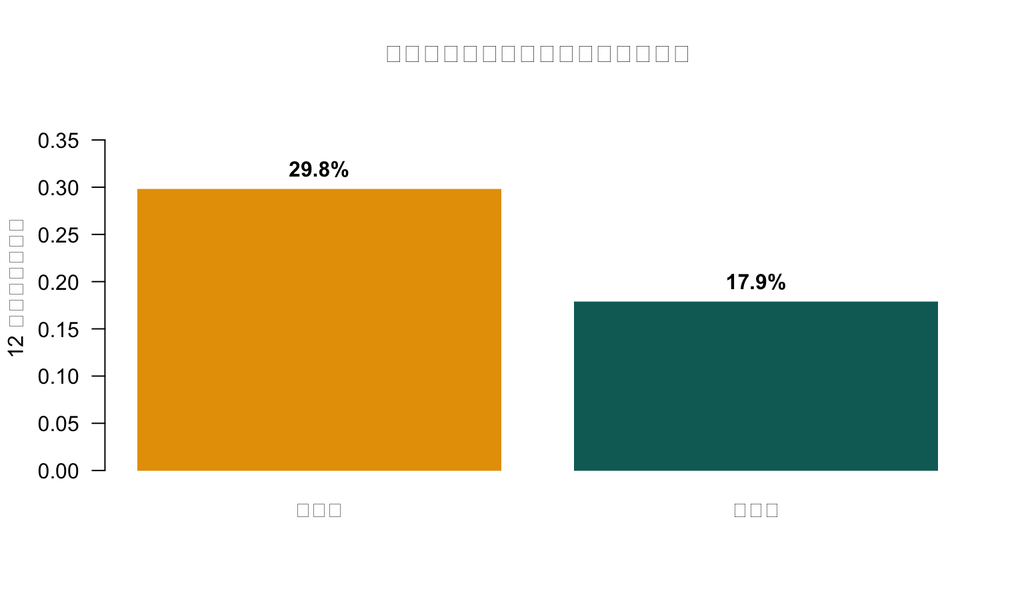

在模拟数据集中，接种者的感染观察风险低于未接种者。

```r
risks <- c("未接种" = risk_unvaccinated, "已接种" = risk_vaccinated)
bar_positions <- barplot(
  risks,
  ylim = c(0, max(risks) * 1.30),
  col = c(palette_ph["orange"], palette_ph["teal"]),
  border = NA,
  ylab = "12 周感染观察风险",
  main = "不同疫苗接种状态的呼吸道感染风险",
  las = 1
)
text(bar_positions, risks, labels = pct(risks), pos = 3, font = 2)
```

## 11.4 第 3 步：结合情境报告估计结果

在 369 名接种者中，感染观察风险为 17.9%；在 151 名未接种者中，该风险为 29.8%。未调整风险比为 0.6（95% 置信区间：0.43 至 0.83），风险差为 -11.9 个百分点（95% 置信区间：-20.2 至 -3.6）。在这个模拟样本中，疫苗接种与较低的感染风险相关。由于疫苗接种并非随机分配，医疗服务可及性、年龄、居住区域、健康行为或其他因素的组间差异可能影响这一关联，因此不能把该结果解释为因果关系的证明。

### 11.4.1 四句话报告模板

> 在**[研究人群]**中，第 1 组的**[结局]**估计值为**[估计值]**，第 0 组为**[估计值]**。估计的**[风险差/风险比/均值差]**为**[数值]**，95% 置信区间为**[下限，上限]**。这提示**[包含单位和时间范围的通俗解释]**。由于数据来自**[研究设计]**，**[具体局限]**可能影响该估计，因此不应假定存在因果关系。

**小型案例反思**

为什么未调整风险比可能与调整后优势比不同？

**答案：** 二者是不同的指标（风险比与优势比），而且调整后模型以年龄、吸烟状态和居住区域为条件。因此，二者的差异既可能反映指标尺度不同，也可能来自协变量调整。模型设定、稀疏亚组和抽样变异也可能造成差异。

# 12 快速参考

## 12.1 核心公式

| 指标 | 公式 | 解释 |
| --- | --- | --- |
| 患病率 | 现有病例数 / 界定的人群数 | 在指定时点或期间患有该病的比例 |
| 累积发病率 | 新发病例数 / 期初处于风险中的人群数 | 规定期间内发生结局的风险 |
| 发病密度 | 新发病例数 / 风险人时 | 新发事件发生的速率 |
| 风险差 | $p_1-p_0$ | 风险的绝对增加或降低 |
| 风险比 | $p_1/p_0$ | 相对风险 |
| 优势比 | 2×2 表中的 $ad/bc$ | 两组优势之比 |
| 均值的标准误估计 | $s/\sqrt{n}$ | 均值抽样变异性的估计 |
| 比例的近似标准误 | $\sqrt{\hat p(1-\hat p)/n}$ | 简单的大样本不确定性近似 |
| 灵敏度 | $TP/(TP+FN)$ | 患病者中检测阳性的比例 |
| 特异度 | $TN/(TN+FP)$ | 未患病者中检测阴性的比例 |
| 阳性预测值（PPV） | $TP/(TP+FP)$ | 检测阳性者中实际患病的比例 |
| 阴性预测值（NPV） | $TN/(TN+FN)$ | 检测阴性者中实际未患病的比例 |

对于小样本或接近 0 或 1 的比例，基本的瓦尔德区间表现可能较差。根据分析目标，得分区间、威尔逊区间或精确法通常更为合适。

## 12.2 方法选择检查清单

选择方法前，应先回答：

- 目标总体和目标估计量是什么？
- 结局属于哪种类型？
- 观测是独立、配对、聚类、重复、删失，还是经过调查加权的？
- 如何测量参与者特征和研究变量？
- 重要数值是否存在缺失？
- 需要哪些分布假设或模型假设？
- 哪种效应尺度容易理解并与决策相关？
- 即使计算无误，仍存在哪些偏倚来源？

## 12.3 通俗术语表

| 术语 | 含义 |
| --- | --- |
| 偏倚 | 使估计值系统性偏离目标量的倾向 |
| 置信区间 | 由旨在量化抽样不确定性的统计程序所产生的区间 |
| 混杂因素 | 因果结构中能够产生或扭曲关联的变量 |
| 估计值 | 根据样本得到的目标参数近似值 |
| 目标估计量 | 分析拟估计的、经过精确定义的量 |
| 可推广性 | 研究结果适用于目标总体或目标情境的程度 |
| 精确度 | 估计值随机变异较小的程度，常由置信区间宽度反映 |
| p 值 | 在模型假设下，数据与零假设相容程度的一种度量 |
| 标准差 | 观测值之间的变异 |
| 标准误 | 统计量抽样变异性的估计 |

# 13 最终知识检验

1. 哪个指标的分母使用人时？
2. 为什么样本均值是统计量而不是参数？
3. 标准差（SD）与标准误（SE）有何区别？
4. 95% 置信区间是否包含 95% 的个体观测值？
5. $p=0.20$ 能否证明两个总体完全相同？
6. 优势比在什么情况下可能与风险比相差很大？
7. 为什么疾病患病率下降时，阳性预测值通常也会下降？
8. 多变量调整能否保证所得结果是因果效应？

**显示最终答案**

1. 发病密度使用风险人时作为分母。
2. 因为它由样本计算得到；总体均值才是参数。
3. 标准差描述观测值之间的变异，标准误描述估计值的不确定性。
4. 不是。置信区间反映参数估计的不确定性，而不是个体观测值的分布。
5. 不能。未拒绝零假设并不能证明两组完全相同；还应考虑估计值、置信区间、检验效能以及有实际意义的等效界值。
6. 当结局常见时。此时优势比可能比相应风险比离 1 更远。
7. 真正病例减少时，即使灵敏度和特异度保持不变，假阳性也可能在全部阳性结果中占据更大比例。
8. 不能。因果解释还需要适当的研究设计、正确的时间顺序、充分的测量、合理的模型设定，以及可辩护的无未测量混杂假设和其他假设。

## 下一步学习方向

公共卫生后续训练可包括样本量规划、调查权重与设计效应、广义线性模型、纵向数据与多层数据、生存分析、空间方法、因果推断、贝叶斯方法、缺失数据方法以及透明报告指南。

**教学用途：**本模块用于介绍统计推理，不能替代在高风险研究或政策决策中向生物统计学家寻求专业咨询。所有数据和数值结果均为模拟结果。可使用页面顶部的按钮下载源 `.Rmd` 文件。